# Iris_(kmeans)

# Why Use a Co-occurrence Matrix?

1. Cluster Stability & Consistency If a pair of samples often end up in the same cluster across different runs, it suggests strong association.

This is useful when the clustering algorithm is non-deterministic (like KMeans).

1. Ensemble Clustering Combine multiple clustering results into a consensus clustering using the co-occurrence matrix.

This can be more robust than a single run.

1. Visualization and Interpretation You can visualize the matrix as a heatmap to understand cluster structure.

Helps see tight clusters or ambiguous points (those that switch clusters often).

1. Input for Hierarchical Clustering You can treat the co-occurrence matrix like a similarity matrix and apply hierarchical clustering on top of it.
2. Noise and Outlier Detection If a sample rarely appears in the same cluster with others, it might be an outlier.

# co consensus clustering with 1 seed point

```python
import pandas as pd
from sklearn.datasets import load_iris
from sklearn.preprocessing import StandardScaler
from sklearn.cluster import KMeans

# Load the iris dataset
iris = load_iris()
X = iris.data
y_true = iris.target
target_names = iris.target_names

# Optional: Convert y_true to labels (setosa, versicolor, virginica)
y_labels = pd.Series([target_names[i] for i in y_true], name="True Label")

# Scale the features
scaler = StandardScaler()
X_scaled = scaler.fit_transform(X)

# Run KMeans clustering with 3 clusters
seed = 42
kmeans = KMeans(n_clusters=3, n_init=10, random_state=seed)
cluster_labels = kmeans.fit_predict(X_scaled)

# Create summary table comparing true labels to clusters
summary_df = pd.crosstab(index=y_labels, columns=cluster_labels,
                         rownames=["True Label (Type)"], colnames=["Cluster"])
summary_df = summary_df.reindex(columns=range(3), fill_value=0)

# Add totals
summary_df['Total'] = summary_df.sum(axis=1)
summary_df.loc['Total'] = summary_df.sum()

# Display result
print("=== True Labels vs Clusters (Iris Dataset, Seed = 42) ===")
print(summary_df)
```

```
=== True Labels vs Clusters (Iris Dataset, Seed = 42) ===
Cluster             0   1   2  Total
True Label (Type)
setosa              0  50   0     50
versicolor         39   0  11     50
virginica          14   0  36     50
Total              53  50  47    150
```

# for 10 seed points

```python
import pandas as pd
from sklearn.datasets import load_iris
from sklearn.preprocessing import StandardScaler
from sklearn.cluster import KMeans

# Load the iris dataset
iris = load_iris()
X = iris.data
y_true = iris.target
target_names = iris.target_names

# Convert numerical labels to string labels
y_labels = pd.Series([target_names[i] for i in y_true], name="True Label")

# Standardize features
scaler = StandardScaler()
X_scaled = scaler.fit_transform(X)

# Run KMeans clustering with 3 clusters
seed = 42
kmeans = KMeans(n_clusters=3, n_init=10, random_state=seed)
cluster_labels = kmeans.fit_predict(X_scaled)

# Create a summary table comparing true species to cluster assignments
summary_df = pd.crosstab(index=y_labels, columns=cluster_labels,
                         rownames=["True Label (Type)"], colnames=["Cluster"])

# Ensure columns 0, 1, 2 exist and fill missing with 0
summary_df = summary_df.reindex(columns=range(3), fill_value=0)

# Add row totals
summary_df['Total'] = summary_df.sum(axis=1)

# Add column totals
summary_df.loc['Total'] = summary_df.sum()

# Display the result
print("True Labels vs Clusters (Iris Dataset, 3 Clusters, Seed = 42) ")
print(summary_df)
```

```
True Labels vs Clusters (Iris Dataset, 3 Clusters, Seed = 42)
Cluster             0   1   2  Total
True Label (Type)
setosa              0  50   0     50
versicolor         39   0  11     50
virginica          14   0  36     50
Total              53  50  47    150
```

```python
import numpy as np
import pandas as pd
from sklearn.datasets import load_iris
from sklearn.preprocessing import StandardScaler
from sklearn.cluster import KMeans

# --- Step 1: Load the Iris dataset ---
iris = load_iris()
X = iris.data
y_true = pd.Series(iris.target, name="True Label")
target_names = iris.target_names
y_labels = pd.Series([target_names[i] for i in y_true], name="True Label")

# --- Step 2: Standardize the features ---
scaler = StandardScaler()
X_scaled = scaler.fit_transform(X)

# --- Step 3: Perform KMeans 10 times with different seeds ---
n_clusters = 3  # Iris has 3 natural classes
for seed in range(10):
    kmeans = KMeans(n_clusters=n_clusters, n_init=10, random_state=seed)
    cluster_labels = kmeans.fit_predict(X_scaled)

    # --- Step 4: Summary table ---
    summary_df = pd.crosstab(index=y_labels, columns=cluster_labels,
                             rownames=["True Label (Type)"], colnames=["Cluster"])
    summary_df = summary_df.reindex(columns=range(n_clusters), fill_value=0)

    # Add row totals
    summary_df['Total'] = summary_df.sum(axis=1)

    # Add column totals
    summary_df.loc['Total'] = summary_df.sum()

    # --- Step 5: Display ---
    print(f"\n=== Run {seed+1}/10 - True Labels vs Cluster Assignments ===")
    print(summary_df)
    print("=" * 100)
```

```
=== Run 1/10 - True Labels vs Cluster Assignments ===
Cluster             0   1   2  Total
True Label (Type)
setosa              0  50   0     50
versicolor         39   0  11     50
virginica          14   0  36     50
Total              53  50  47    150
====================================================================================================

=== Run 2/10 - True Labels vs Cluster Assignments ===
Cluster             0   1   2  Total
True Label (Type)
setosa              0  50   0     50
versicolor         11   0  39     50
virginica          36   0  14     50
Total              47  50  53    150
====================================================================================================

=== Run 3/10 - True Labels vs Cluster Assignments ===
Cluster             0   1   2  Total
True Label (Type)
setosa              0  50   0     50
versicolor         39   0  11     50
virginica          14   0  36     50
Total              53  50  47    150
====================================================================================================

=== Run 4/10 - True Labels vs Cluster Assignments ===
Cluster             0   1   2  Total
True Label (Type)
setosa              0  50   0     50
versicolor         39   0  11     50
virginica          14   0  36     50
Total              53  50  47    150
====================================================================================================

=== Run 5/10 - True Labels vs Cluster Assignments ===
Cluster             0   1   2  Total
True Label (Type)
setosa              0  50   0     50
```

[output cut: 34 more lines]

```
True Label (Type)
setosa              0  50   0     50
versicolor         39   0  11     50
virginica          14   0  36     50
Total              53  50  47    150
====================================================================================================

=== Run 10/10 - True Labels vs Cluster Assignments ===
Cluster             0   1   2  Total
True Label (Type)
setosa             50   0   0     50
versicolor          0  39  11     50
virginica           0  14  36     50
Total              50  53  47    150
====================================================================================================
```

# co consensus k means clustering

```python
import numpy as np
import pandas as pd
from sklearn.datasets import load_iris
from sklearn.cluster import KMeans
from sklearn.preprocessing import StandardScaler

# Load and scale Iris data
iris = load_iris()
X = iris.data
y_true = pd.Series([iris.target_names[i] for i in iris.target], name="True Label (Type)")

scaler = StandardScaler()
X_scaled = scaler.fit_transform(X)

# Step 1: Create a co-consensus matrix by running KMeans multiple times
n_runs = 20
n_clusters = 3
n_samples = X_scaled.shape[0]
consensus_matrix = np.zeros((n_samples, n_samples))

# Run KMeans multiple times and update co-assignment frequencies
for seed in range(n_runs):
    kmeans = KMeans(n_clusters=n_clusters, n_init=1, random_state=seed)
    labels = kmeans.fit_predict(X_scaled)
    for i in range(n_samples):
        for j in range(n_samples):
            if labels[i] == labels[j]:
                consensus_matrix[i, j] += 1

# Normalize the consensus matrix to range [0, 1]
consensus_matrix /= n_runs

# Step 2: Treat each row of consensus_matrix as a data point and apply KMeans
kmeans_final = KMeans(n_clusters=3, n_init=10, random_state=42)
cluster_labels = kmeans_final.fit_predict(consensus_matrix)

# Step 3: Summary table (True Label vs Cluster)
summary_df = pd.crosstab(index=y_true, columns=cluster_labels,
                         rownames=["True Label (Type)"], colnames=["Cluster"])
summary_df = summary_df.reindex(columns=range(3), fill_value=0)

# Add totals
summary_df['Total'] = summary_df.sum(axis=1)
summary_df.loc['Total'] = summary_df.sum()

# Display the result
print("=== True Labels vs Clusters (from Consensus Matrix) ===")
print(summary_df)
```

```
=== True Labels vs Clusters (from Consensus Matrix) ===
Cluster             0   1   2  Total
True Label (Type)
setosa              0  50   0     50
versicolor         12   0  38     50
virginica          39   0  11     50
Total              51  50  49    150
```

# decision tree

```
=== True Labels vs Clusters (Consensus Matrix) ===
Cluster            0  1  2  Total
True Label (Type)
Setosa             0  0  1      1
Versicolor         1  0  0      1
Virginica          0  1  0      1
Total              1  1  1      3

Decision Tree Accuracy: 1.0

Classification Report:
               precision    recall  f1-score   support

           0       1.00      1.00      1.00         1
           1       1.00      1.00      1.00         1
           2       1.00      1.00      1.00         1

    accuracy                           1.00         3
   macro avg       1.00      1.00      1.00         3
weighted avg       1.00      1.00      1.00         3
```

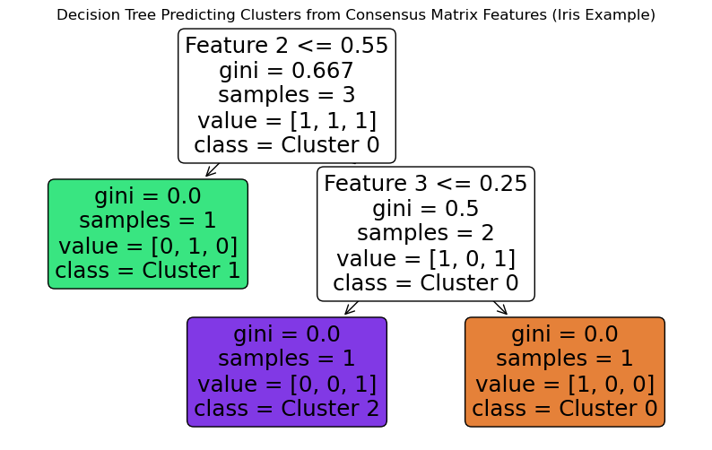

```python
import numpy as np
import pandas as pd
from sklearn.cluster import KMeans
from sklearn.tree import DecisionTreeClassifier, plot_tree
from sklearn.metrics import classification_report, accuracy_score
import matplotlib.pyplot as plt

# === Step 1: Synthetic consensus matrix (3x3) for Iris example ===
consensus_matrix = np.array([
    [1.0, 0.8, 0.2],
    [0.8, 1.0, 0.3],
    [0.2, 0.3, 1.0]
])

# === Step 2: True labels for the 3 data points ===
y_true = pd.Series(['Setosa', 'Versicolor', 'Virginica'])

# === Step 3: KMeans clustering with 3 clusters ===
kmeans = KMeans(n_clusters=3, n_init=10, random_state=42)
cluster_labels = kmeans.fit_predict(consensus_matrix)

# Print clustering summary
summary_df = pd.crosstab(index=y_true, columns=cluster_labels,
                         rownames=["True Label (Type)"], colnames=["Cluster"])
summary_df = summary_df.reindex(columns=range(3), fill_value=0)
summary_df['Total'] = summary_df.sum(axis=1)
summary_df.loc['Total'] = summary_df.sum()
print("=== True Labels vs Clusters (Consensus Matrix) ===")
print(summary_df)

# === Step 4: Train Decision Tree to predict cluster labels from consensus features ===
dtree = DecisionTreeClassifier(random_state=42)
dtree.fit(consensus_matrix, cluster_labels)

# Predict on the same data
y_pred = dtree.predict(consensus_matrix)

# Accuracy & report
print("\nDecision Tree Accuracy:", accuracy_score(cluster_labels, y_pred))
print("\nClassification Report:\n", classification_report(cluster_labels, y_pred))

# === Step 5: Plot the decision tree ===
plt.figure(figsize=(10,6))
plot_tree(dtree,
          feature_names=[f"Feature {i+1}" for i in range(consensus_matrix.shape[1])],
          class_names=[f"Cluster {i}" for i in range(3)],
          filled=True, rounded=True)
plt.title("Decision Tree Predicting Clusters from Consensus Matrix Features (Iris Example)")
plt.show()
```

```python
import numpy as np
from sklearn.datasets import load_iris

# Load iris dataset
iris = load_iris()
X = iris.data
y = iris.target
data = np.column_stack((X, y))  # Combine features and labels
```

```python
# Check if node is pure (only one class)
def is_pure(data):
    return len(set(data[:, -1])) == 1

# Split data
def split_data(data, feature, threshold):
    left = data[data[:, feature] <= threshold]
    right = data[data[:, feature] > threshold]
    return left, right

# Gini impurity
def gini(data):
    labels = data[:, -1]
    classes, counts = np.unique(labels, return_counts=True)
    probs = counts / len(labels)
    return 1 - np.sum(probs**2)

# Weighted Gini of a split
def weighted_gini(left, right):
    total = len(left) + len(right)
    return (len(left)/total)*gini(left) + (len(right)/total)*gini(right)

# Find best split
def best_split(data):
    best_feature, best_threshold, best_score = None, None, 1
    n_features = data.shape[1] - 1

    for feature in range(n_features):
        values = np.unique(data[:, feature])
        for val in values:
            left, right = split_data(data, feature, val)
            if len(left) == 0 or len(right) == 0:
                continue
            score = weighted_gini(left, right)
            if score < best_score:
                best_feature, best_threshold, best_score = feature, val, score

    return best_feature, best_threshold
```

```python
def build_tree(data, depth=0):
    if is_pure(data) or len(data) == 0:
        # Return majority class
        labels, counts = np.unique(data[:, -1], return_counts=True)
        return int(labels[np.argmax(counts)])

    feature, threshold = best_split(data)
    if feature is None:
        # No more split possible
        labels, counts = np.unique(data[:, -1], return_counts=True)
        return int(labels[np.argmax(counts)])

    left, right = split_data(data, feature, threshold)

    return {
        'feature': feature,
        'threshold': threshold,
        'left': build_tree(left, depth+1),
        'right': build_tree(right, depth+1)
    }
```

```python
def print_tree(tree, depth=0):
    indent = "  " * depth
    if isinstance(tree, dict):
        print(f"{indent}[X{tree['feature']} <= {tree['threshold']}]")
        print_tree(tree['left'], depth+1)
        print_tree(tree['right'], depth+1)
    else:
        print(f"{indent}--> Predict: {iris.target_names[int(tree)]}")
```

```python
tree = build_tree(data)
print_tree(tree)
```

```
[X2 <= 1.9]
  --> Predict: setosa
  [X3 <= 1.7]
    [X2 <= 4.9]
      [X3 <= 1.6]
        --> Predict: versicolor
        --> Predict: virginica
      [X3 <= 1.5]
        --> Predict: virginica
        [X0 <= 6.7]
          --> Predict: versicolor
          --> Predict: virginica
    [X2 <= 4.8]
      [X0 <= 5.9]
        --> Predict: versicolor
        --> Predict: virginica
      --> Predict: virginica
```

```python
from sklearn.datasets import load_iris
import pandas as pd

# Load the Iris dataset
iris = load_iris()
X = pd.DataFrame(iris.data, columns=iris.feature_names)
y = iris.target
target_names = iris.target_names

# Rename features for readability
X.columns = ['X0', 'X1', 'X2', 'X3']  # sepal length, sepal width, petal length, petal width

# Custom decision function based on your tree
def predict_custom(row):
    if row['X2'] <= 1.9:
        return 'setosa'
    else:
        if row['X3'] <= 1.7:
            if row['X2'] <= 4.9:
                if row['X3'] <= 1.6:
                    return 'versicolor'
                else:
                    return 'virginica'
            else:
                if row['X3'] <= 1.5:
                    return 'virginica'
                else:
                    if row['X0'] <= 6.7:
                        return 'versicolor'
                    else:
                        return 'virginica'
        else:
            if row['X2'] <= 4.8:
                if row['X0'] <= 5.9:
                    return 'versicolor'
                else:
                    return 'virginica'
            else:
                return 'virginica'

# Apply custom prediction
X['Predicted'] = X.apply(predict_custom, axis=1)
X['Actual'] = [target_names[i] for i in y]

# Evaluate accuracy
accuracy = (X['Predicted'] == X['Actual']).mean()
print(f"Custom Tree Accuracy: {accuracy:.2f}")

# Show few predictions
print(X[['Predicted', 'Actual']].head(10))
```

```
Custom Tree Accuracy: 1.00
  Predicted  Actual
0    setosa  setosa
1    setosa  setosa
2    setosa  setosa
3    setosa  setosa
4    setosa  setosa
5    setosa  setosa
6    setosa  setosa
7    setosa  setosa
8    setosa  setosa
9    setosa  setosa
```